# Data 622 - Week 4 Discussion - LDA vs Logistic Regression

William Jasmine

2024-02-25

# Libraries and setup

```r
library(tidyverse)
library(ISLR)
library(MASS)
library(ggplot2)
library(data.table)
seed_num <- 42
```

# Example - LDA vs BLR

First, the cell below creates two normally distributed predictor variables, $x_1$ and $x_2$. 1,000 samples are generated for each.

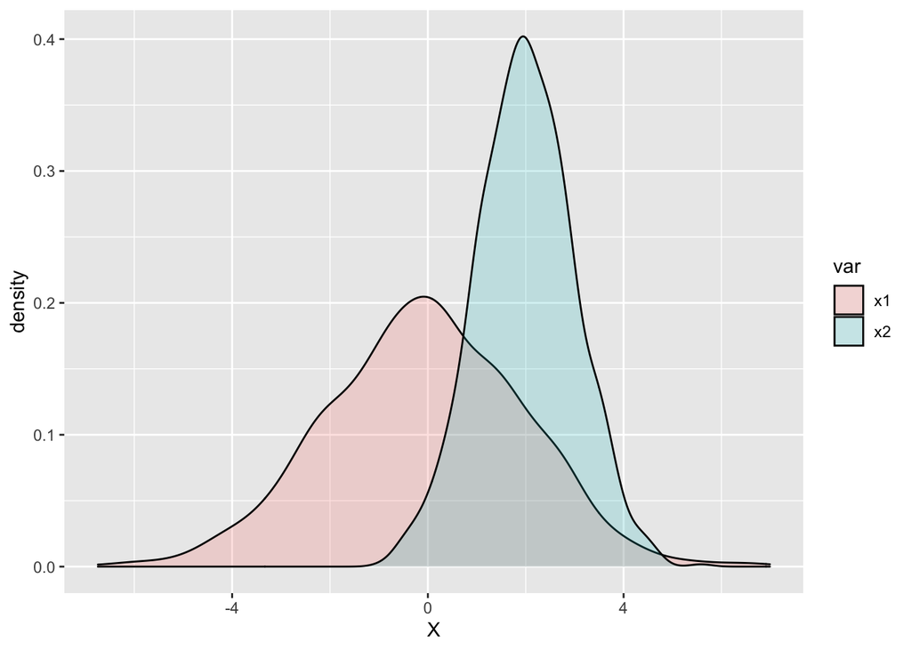

```r
set.seed(seed_num)

# x1_c1 <- rnorm(100, 0)
# x2_c1 <- rnorm(100, 8)
#
# x1_c2 <- rnorm(100, 4)
# x2_c2 <- rnorm(100, 12)
#
# x1 <- c(x1_c1, x1_c2)
# x2 <- c(x2_c1, x2_c2)

x1 <- rnorm(1000, 0, 2)
x2 <- rnorm(1000, 2, 1)


p1 <- data.frame(X = x1)
p2 <- data.frame(X = x2)
p1$var <- 'x1'
p2$var <- 'x2'
plt_df <- rbind(p1, p2)
ggplot(plt_df, aes(X, fill = var)) + geom_density(alpha = 0.2)
```

We see from the density plots above that both predictors appear normal with differing $\mu$ and $\sigma$. Note that normally distributed predictors is one of the assumptions of linear discriminant analysis (LDA), which is not true of binomial logistic regression (BLR).

The cell below uses a line of slope $m = -0.2$ and y-intercept $b = 2$ to create a hypothetical border separating the points into two separate classes.

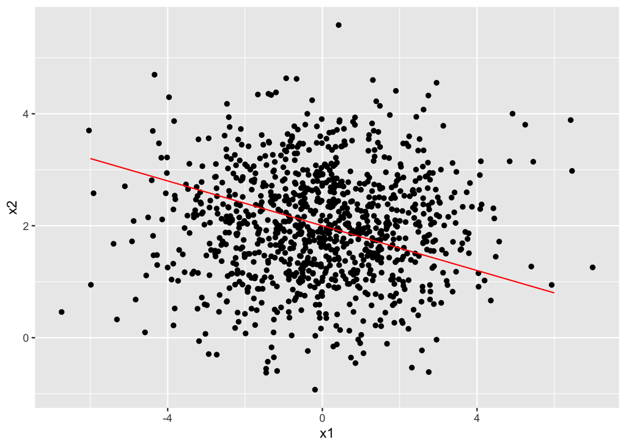

```r
cutoff_x <- seq(-6, 6, length.out = 1000)
m <- -0.2
b <- 2
# m <- -2
# b <- 14
cutoff_y <- (m * cutoff_x) + b
df <- data.frame(x1 = x1, x2 = x2, cutoff_x = cutoff_x, cutoff_y = cutoff_y)
plt <- ggplot(data = df) +
  geom_point(aes(x=x1, y=x2)) +
  geom_line(aes(x=cutoff_x, y=cutoff_y), color='red')
plt
```

Using this line to separate the points gives the following:

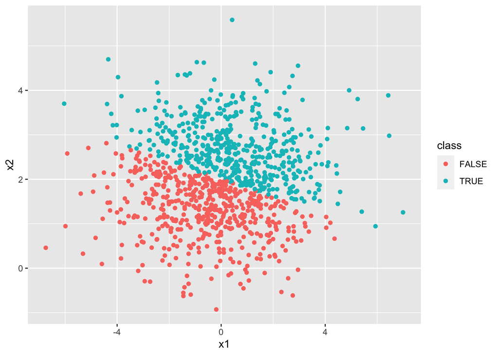

```r
df <- df  %>% mutate(
  class = case_when(
    x2 < m * x1 + b ~ FALSE,
    TRUE ~ TRUE
  )
)

plt <- ggplot(data = df) +
  geom_point(aes(x=x1, y=x2, color=class))
plt
```

To prevent there being a perfect linear separation between the two classes (logistic regression will not work if this is the case) the cell below randomly switches the class of 50 of the data points, and updates the plot:

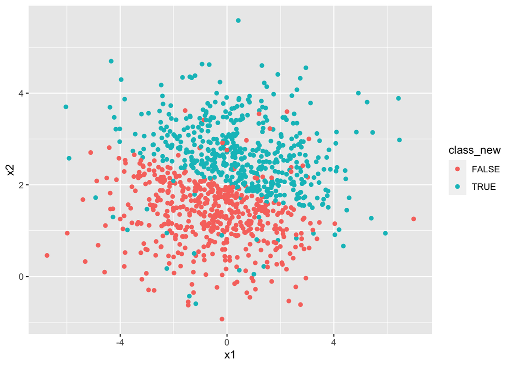

```r
set.seed(seed_num)
df$class_new <- df$class
changes <- floor(runif(50, min=0, nrow(df)))
for (change in changes) {
  df$class_new[change] <- !df$class_new[change]
}

plt <- ggplot(data = df) +
  geom_point(aes(x=x1, y=x2, color=class_new))
plt
```

We see that the covariance matrices of the individual classes are the essentially the same, which is another assumption of LDA (note that so long as the points that switch class are chosen at random, this should always hold true).

```r
cov1 <- cov(dplyr::select(filter(df, class_new==1), x1, x2))
cov2 <- cov(dplyr::select(filter(df, class_new==0), x1, x2))
print(cov1)
```

```
##            x1         x2
## x1  3.9639640 -0.3983963
## x2 -0.3983963  0.6240523
```

```r
print(cov2)
```

```
##            x1         x2
## x1  3.4805729 -0.2666029
## x2 -0.2666029  0.5071406
```

Next, the cell below separates the data into training and testing datasets.

```r
# define training data cutoff
train_size = 0.75
cutoff = floor(train_size * nrow(df))

# split data randomly into train and test set
set.seed(1234)
tmp_df <- dplyr::select(df, x1, x2, class_new)
train_ind <- sample(seq_len(nrow(df)), size=cutoff)
train <- tmp_df[train_ind, ]
test <- tmp_df[-train_ind, ]
```

First, the BLR model is fitted using the training data:

```r
blr <- glm(class_new ~ x1 + x2, data = train, family = "binomial")
summary(blr)
```

```
##
## Call:
## glm(formula = class_new ~ x1 + x2, family = "binomial", data = train)
##
## Deviance Residuals:
##     Min       1Q   Median       3Q      Max
## -3.3204  -0.5185   0.0169   0.5208   4.1033
##
## Coefficients:
##             Estimate Std. Error z value Pr(>|z|)
## (Intercept)  -5.8866     0.4563 -12.901   <2e-16 ***
## x1            0.6430     0.0678   9.484   <2e-16 ***
## x2            2.9943     0.2246  13.329   <2e-16 ***
## ---
## Signif. codes:  0 '***' 0.001 '**' 0.01 '*' 0.05 '.' 0.1 ' ' 1
##
## (Dispersion parameter for binomial family taken to be 1)
##
##     Null deviance: 1039.67  on 749  degrees of freedom
## Residual deviance:  527.66  on 747  degrees of freedom
## AIC: 533.66
##
## Number of Fisher Scoring iterations: 6
```

Followed by the LDA model:

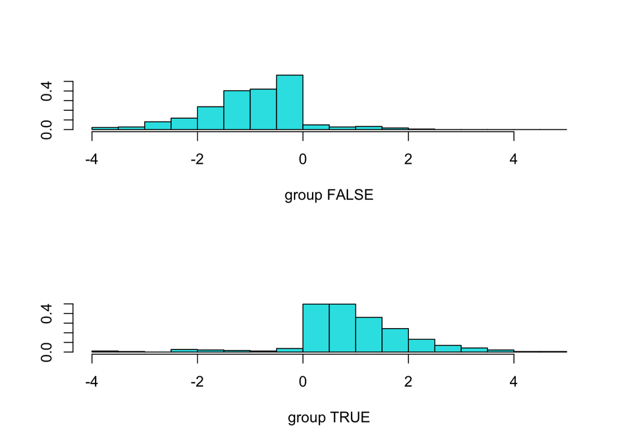

```r
lda <- lda(class_new ~ x1 + x2, data = train)
plot(lda)
```

We can use this fitted models to see how well they perform on the test dataset:

```r
preds <- data.frame(true = test$class_new)
preds$blr_prob <- predict(blr, newdata = test, type = "response")

preds <- preds %>%
  mutate(blr_pred = ifelse(blr_prob>.5, TRUE, FALSE))

preds$lda_pred <- data.frame(predict(lda, newdata = test))$class

blr_tab <- table(preds$true, preds$blr_pred)
lda_tab <- table(preds$true, preds$lda_pred)

blr_score <- sum(diag(blr_tab)) / nrow(preds)
lda_score <- sum(diag(lda_tab)) / nrow(preds)
print(lda_score)
```

```
## [1] 0.948
```

```r
print(blr_score)
```

```
## [1] 0.948
```

# Comparing Different $n$ and $N$

We can see that both the LDA and BLR models did quite well in predicting the outcomes of the test dataset. However, to test which does better in certain scenarios the cell below defines a function to compare the score of each when modifying $N$ (the number of observations) and $n$ (the number of randomly chosen observations that have their class switched). Thus, we can see how the models differ with different sample sizes and varying levels of class separation.

```r
compare_lda_blr <- function(N, n){

  x1 <- rnorm(N, 0, 2)
  x2 <- rnorm(N, 2, 1)

  cutoff_x <- seq(-6, 6, length.out = N)
  m <- -0.2
  b <- 2
  cutoff_y <- (m * cutoff_x) + b
  df <- data.frame(x1 = x1, x2 = x2, cutoff_x = cutoff_x, cutoff_y = cutoff_y)

  df <- df  %>% mutate(
    class = case_when(
      x2 < m * x1 + b ~ FALSE,
      TRUE ~ TRUE
    )
  )

  # randomly change some of the classes
  df$class_new <- df$class
  changes <- floor(runif(n, min=0, nrow(df)))
  for (change in changes) {
    df$class_new[change] <- !df$class_new[change]
  }

  train_size = 0.75
  cutoff = floor(train_size * nrow(df))

  # split data randomly into train and test set
  tmp_df <- dplyr::select(df, x1, x2, class_new)
  train_ind <- sample(seq_len(nrow(df)), size=cutoff)
  train <- tmp_df[train_ind, ]
  test <- tmp_df[-train_ind, ]

  blr <- glm(class_new ~ x1 + x2, data = train, family = "binomial")
  lda <- lda(class_new ~ x1 + x2, data = train)

  preds <- data.frame(true = test$class_new)

  preds$blr_prob <- predict(blr, newdata = test, type = "response")
  preds <- preds %>%
    mutate(blr_pred = ifelse(blr_prob>.5, TRUE, FALSE))

  preds$lda_pred <- data.frame(predict(lda, newdata = test))$class

  blr_tab <- table(preds$true, preds$blr_pred)
  lda_tab <- table(preds$true, preds$lda_pred)

  blr_score <- sum(diag(blr_tab)) / nrow(preds)
  lda_score <- sum(diag(lda_tab)) / nrow(preds)

  return(c(n, blr_score, lda_score))
}
```

The cell below uses this function to show how the accuracy scores using LDA and BLR change when $N=1000$ for different values of $n$.

```r
blr_scores <- c()
lda_scores <- c()
ns <- seq(1, 500)

for (n in ns){
  run <- compare_lda_blr(1000, n)
  blr_scores[n] <- run[2]
  lda_scores[n] <- run[3]
}

n_df <- data.frame(blr_scores =  blr_scores,
                      lda_scores = lda_scores,
                      ns = ns)
```

When plotting the results, we see that there is very little difference in the results of LDA vs BLR. The accuracy of both models decreases with larger $n$ due to less extreme class separation, but there tends to be not deviation between the two at any value of $n$.

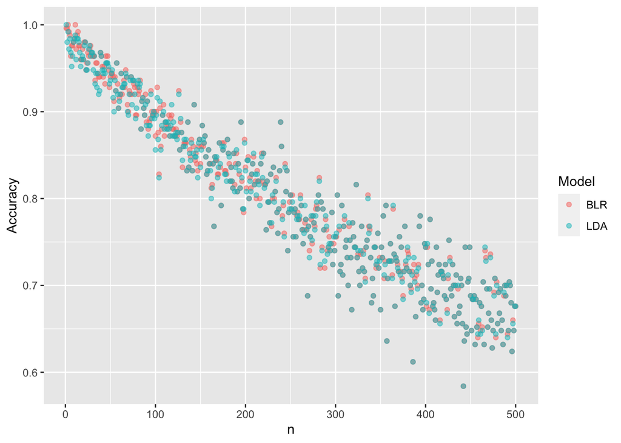

```r
plt_data <- n_df
colnames(plt_data) <- c('BLR', 'LDA', 'n')
plt_data <- melt(plt_data, id.vars = c('n'),
                 variable.name = 'Model',
                 value.name = 'Accuracy')
ggplot(data=plt_data) +
  geom_point(aes(x=n, y=Accuracy, color=Model), alpha=0.5)
```

```r
blr_scores <- c()
lda_scores <- c()
start <- 50
Ns <- seq(start, 500)

for (N in Ns){
  run <- compare_lda_blr(N, floor(N*0.20))
  blr_scores[N-start+1] <- run[2]
  lda_scores[N-start+1] <- run[3]
}

N_df <- data.frame(blr_scores =  blr_scores,
                   lda_scores = lda_scores,
                   Ns = Ns)
```

The plotted results provide an interesting result: in general the results for both models get better as the sample size increases, but their dot plot makes a strange repreating curve like structure that I am not able to explain.

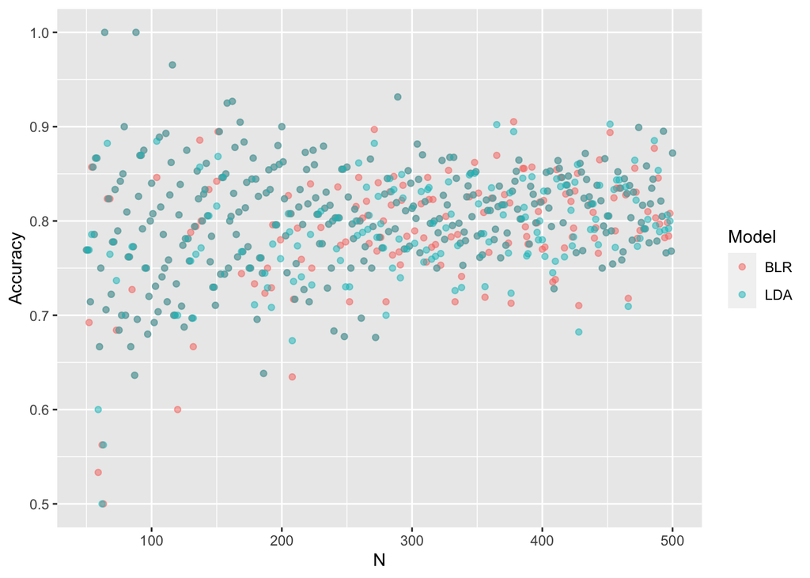

```r
plt_data <- N_df
colnames(plt_data) <- c('BLR', 'LDA', 'N')
plt_data <- melt(plt_data, id.vars = c('N'),
                 variable.name = 'Model',
                 value.name = 'Accuracy')
ggplot(data=plt_data) +
  geom_point(aes(x=N, y=Accuracy, color=Model), alpha=0.5)
```

# Thoughts and Conclusions

The next step I could take in this analysis is to include QDA and include cases in which the hypothetical border between classes is non linear. QDA does not have the same constant covariance condition as LDA, which is why it is able to draw these non-linear decision boundaries. Thus, while LDA and logistic regression might be quicker and more accurate models when faced with classes of constant covariance, QDA should win the day if this is not the case.